#Import libraries and the example DF

```r
library(tidyverse)
library(ggpubr)
#We load in a long format as described in chapter 1.
exampleDF <- read_csv("exampleDF.csv")
```

```
## ──────────────────────────────────────────────────────── Delimiter: "," chr
## (2): Sample, Protein dbl (2): ...1, Intensity
```

# Outlier Removal

Hanno (Steen) and I developed this method once to select outliers. The following steps are done:

1. For each protein in the dataset, calculate the median. Thus we create an ‘additional sample’ which is composed of all median values.
2. Correlate each sample to this created median-sample
3. We calculate the standard deviation of all these correlations
4. We multiply this standard deviation based on how strict we want it. If a sample is x standard deviations away, we consider it an outlier.

This function therefore requires the dataset, the standard deviation strictness and a name since it will also plot (PCA) the data.

### Function

```r
OutlierRemover <- function(dataset, Stdv, name){

  #Determine correlations between sample and theoretical
  SampleCorrelations <- dataset%>%
    group_by(Protein) %>%
    dplyr::mutate(medianProtein = median(Intensity, na.rm = T)) %>%
    ungroup() %>%
    group_by(Sample) %>%
    dplyr::mutate(SampleCor = stats::cor(Intensity, medianProtein, method = "pearson", use="pairwise.complete.obs")) %>%
    ungroup() %>%
    distinct(Sample, .keep_all = T)

  SampleCorrelations <- SampleCorrelations %>%
    dplyr::mutate(Outlier = SampleCor < (1 - Stdv*sd(unique(SampleCorrelations$SampleCor), na.rm = T)))

  #Make the DF that we will return (i.e. without outliers)
  returnDataset <- dataset %>%
    dplyr::filter(Sample %in% dplyr::filter(SampleCorrelations, Outlier == F)$Sample) %>%
    dplyr::select(Protein, Sample, Intensity)

  #Purely for visualization: Also attached PCA Plots of the removed samples

  #Half minimum value (per protein) imputation
  PCA_DF <- dataset %>%
    group_by(Protein) %>%
    dplyr::mutate(IntensImputed = replace_na(Intensity, mean(Intensity, na.rm = T)/2)) %>%
    dplyr::select(Protein, Sample, IntensImputed) %>%
    spread(key = "Protein", value = "IntensImputed") %>%
    column_to_rownames("Sample")

  #scale and PCA
  PCA_DF_Results <- prcomp(scale(as.matrix(PCA_DF)))
  eigs <- PCA_DF_Results$sdev^2
  variance_percentage <- (eigs / sum(eigs))*100
  pc1var <- round(variance_percentage[1],digits=0)
  pc2var <- round(variance_percentage[2],digits=0)

  #Plot
  plot(left_join(SampleCorrelations, rownames_to_column(data.frame(PCA_DF_Results$x)), by = c("Sample" = "rowname")) %>%
         ggplot(aes(x = PC1, y = PC2, colour = Outlier, shape = Outlier)) +
         geom_point(size = 2.5, alpha = 0.6) +
         theme_bw() +
         xlab(paste('PC1',' (',pc1var,'% variance)',sep='')) +
         ylab(paste('PC2',' (',pc2var,'% variance)',sep='')) +
         scale_color_manual(values = c("black", "red")) +
         ggtitle(name))

  #Print and Return
  print(paste("The following were removed from:", name, toString(dplyr::filter(SampleCorrelations, Outlier == T)$Sample)))
  return(returnDataset)
}
```

### Usage

```r
example_without_outliers <- OutlierRemover(
  exampleDF,
  Stdv = 3,
  name = "Example Outlier Removal"
)
```

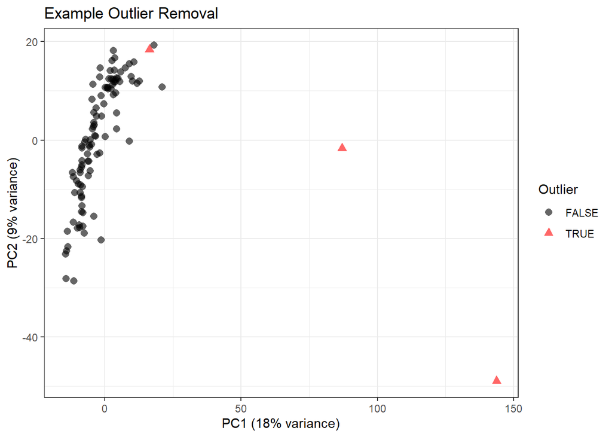

```
## [1] "The following were removed from: Example Outlier Removal DIA_31_S5-D5_1_12233, DIA_54_S6-A2_1_12258, DIA_77_S6-C5_1_12281"
```

# Normalization

I’ve made a few normalization methods. Here I describe each of them.

## Normalize - based on pool

In house made normalization method on pool samples.

```r
#Based on the pool. Requires user to give string_of_pool with ONE systematic naming convention.
normalize_basedonpool <- function(dataset, string_of_pool){

  #First calculate per sample the median intensity.
  #Then take the mean of all those medians.
  dataset_references <-
    dataset %>%
    mutate(Intensity = 2^Intensity)%>%
    dplyr::filter(grepl(string_of_pool, Sample)) %>%
    group_by(Sample) %>%
    summarise(PerSampleMedian = median(Intensity, na.rm = TRUE)) %>%
    ungroup() %>%
    summarise(AverageMedian = mean(PerSampleMedian))


  #Only select samples, calculate median per sample.
  #Determine per sample normalization factor
  #apply it to intensity column.
  #clean up.
  dataset_noreferences <-
    dataset %>%
    mutate(Intensity = 2^Intensity)%>%
    dplyr::filter(!grepl(string_of_pool, Sample)) %>%
    group_by(Sample) %>%
    mutate(PerSampleMedian = median(Intensity, na.rm = TRUE)) %>%
    mutate(NormalizeFactor = dataset_references[[1,1]]/ PerSampleMedian) %>%
    mutate(Intensity = Intensity * NormalizeFactor) %>%
    ungroup() %>%
    mutate(Intensity = log2(Intensity)) %>%
    dplyr::select(Protein, Sample, Intensity)

  boxplot_before <-
    dataset %>%
    dplyr::filter(!grepl(string_of_pool, Sample)) %>%
    ggplot(aes(x = Sample, y = Intensity)) +
    geom_boxplot() +
    theme_bw() +
    theme(axis.ticks.x = element_blank(), axis.text.x = element_blank()) +
    ggtitle("before Normalization") +
    ylab("log2(Intensity)")

  boxplot_after <-
    dataset_noreferences %>%
    ggplot(aes(x = Sample, y = Intensity)) +
    geom_boxplot() +
    theme_bw() +
    theme(axis.ticks.x = element_blank(), axis.text.x = element_blank()) +
    ggtitle("after Normalization") +
    ylab("log2(Intensity)")

  plot(ggarrange(boxplot_before, boxplot_after, nrow = 1))

  return(dataset_noreferences)
}
```

### Usage

```r
example_without_outliers_normalized_pool <- normalize_basedonpool(example_without_outliers, string_of_pool = "Pool")
```

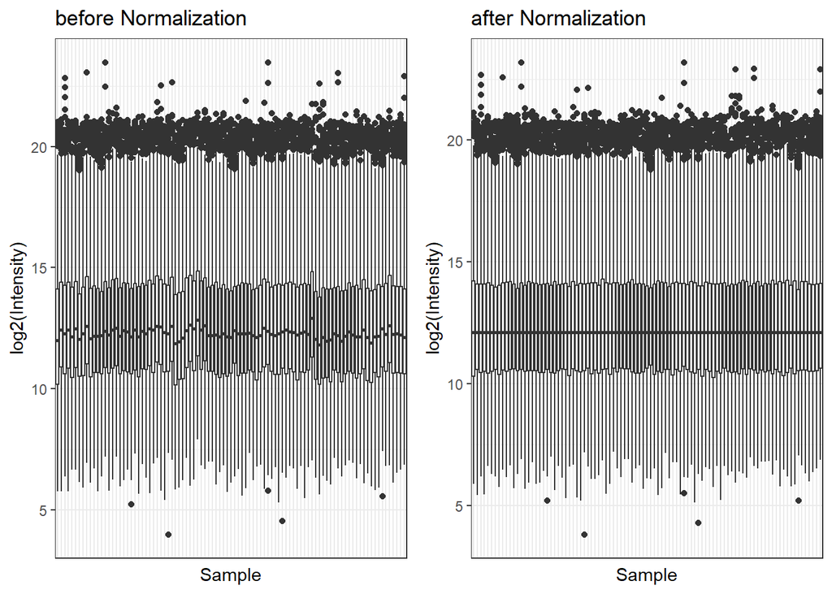

## Normalize - summed intensity

Normalize by calculating median of all summed intensities. Normalize to per sample sum.

```r
#User can also remove pool (standard = "")

normalize_summedintensity <- function(dataset, string_of_pool = ""){

  dataset_medianSummedIntensity <- dataset %>%
    mutate_all(~replace(., . == 0, NA)) %>%
    mutate(Intensity = 2^Intensity)%>%
    group_by(Sample) %>%
    summarise(PerSampleSum = sum(Intensity, na.rm = TRUE)) %>%
    ungroup() %>%
    summarise(medianOfSummedIntensities = median(PerSampleSum))

  if (string_of_pool != ""){
    print("Info on Pools were included. They are used to determine summed Intensity but removed downstream.")
    dataset <- dataset %>%
      dplyr::filter(!grepl(string_of_pool, Sample))
  }

  dataset_normalized <-
    dataset %>%
    mutate(Intensity = 2^Intensity) %>%
    group_by(Sample) %>%
    mutate(PerSampleSum = sum(Intensity, na.rm = TRUE)) %>%
    mutate(NormalizeFactor = dataset_medianSummedIntensity[[1,1]]/ PerSampleSum) %>%
    mutate(Intensity = Intensity * NormalizeFactor) %>%
    ungroup() %>%
    dplyr::select(Protein, Sample, Intensity) %>%
    mutate_all(~replace(., . == 0, NA)) %>%
    mutate(Intensity = log2(Intensity))

  boxplot_before <-
    dataset %>%
    ggplot(aes(x = Sample, y = Intensity)) +
    geom_boxplot() +
    theme_bw() +
    theme(axis.ticks.x = element_blank(), axis.text.x = element_blank()) +
    ggtitle("before Normalization") +
    ylab("log2(Intensity)")

  boxplot_after <-
    dataset_normalized %>%
    ggplot(aes(x = Sample, y = Intensity)) +
    geom_boxplot() +
    theme_bw() +
    theme(axis.ticks.x = element_blank(), axis.text.x = element_blank()) +
    ggtitle("before Normalization") +
    ylab("log2(Intensity)")

  plot(ggarrange(boxplot_before, boxplot_after, nrow = 1))

  return(dataset_normalized)
}
```

### Usage

```r
example_without_outliers_normalized_summedIntens_withPool <- normalize_summedintensity(example_without_outliers, string_of_pool = "Pool")
```

```
## [1] "Info on Pools were included. They are used to determine summed Intensity but removed downstream."
```

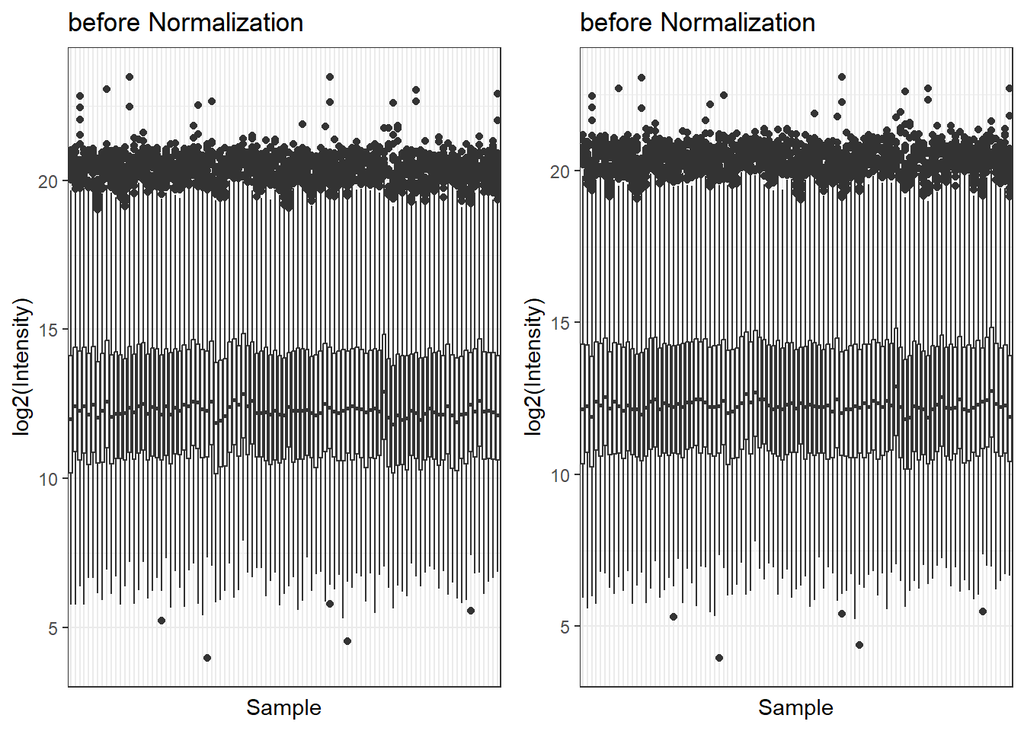

```r
#OR if you do not have pool dont specify and it wont delete them.

example_without_outliers_normalized_summedIntens_withPool <- normalize_summedintensity(example_without_outliers)
```

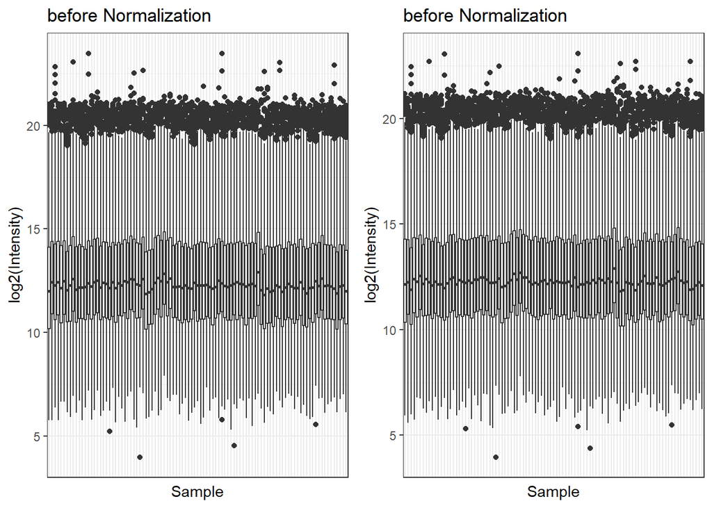

## Normalize - Median Intensity

```r
#User can also remove pool (standard = "")

normalize_medianintensity <- function(dataset, string_of_pool = ""){

  dataset_medianSummedIntensity <- dataset %>%
    mutate_all(~replace(., . == 0, NA)) %>%
    mutate(Intensity = 2^Intensity)%>%
    group_by(Sample) %>%
    summarise(PerSampleSum = median(Intensity, na.rm = TRUE)) %>%
    ungroup() %>%
    summarise(medianOfSummedIntensities = median(PerSampleSum))

  if (string_of_pool != ""){
    print("Info on Pools were included. They are used to determine summed Intensity but removed downstream.")
    dataset <- dataset %>%
      dplyr::filter(!grepl(string_of_pool, Sample))
  }

  dataset_normalized <-
    dataset %>%
    mutate(Intensity = 2^Intensity) %>%
    group_by(Sample) %>%
    mutate(PerSampleSum = median(Intensity, na.rm = TRUE)) %>%
    mutate(NormalizeFactor = dataset_medianSummedIntensity[[1,1]]/ PerSampleSum) %>%
    mutate(Intensity = Intensity * NormalizeFactor) %>%
    ungroup() %>%
    dplyr::select(Protein, Sample, Intensity) %>%
    mutate_all(~replace(., . == 0, NA)) %>%
    mutate(Intensity = log2(Intensity))

  boxplot_before <-
    dataset %>%
    ggplot(aes(x = Sample, y = Intensity)) +
    geom_boxplot() +
    theme_bw() +
    theme(axis.ticks.x = element_blank(), axis.text.x = element_blank()) +
    ggtitle("before Normalization") +
    ylab("log2(Intensity)")

  boxplot_after <-
    dataset_normalized %>%
    ggplot(aes(x = Sample, y = Intensity)) +
    geom_boxplot() +
    theme_bw() +
    theme(axis.ticks.x = element_blank(), axis.text.x = element_blank()) +
    ggtitle("before Normalization") +
    ylab("log2(Intensity)")

  plot(ggarrange(boxplot_before, boxplot_after, nrow = 1))

  return(dataset_normalized)
}
```

### Usage

```r
example_without_outliers_normalized_medianIntens_withPool <- normalize_medianintensity(example_without_outliers, string_of_pool = "Pool")
```

```
## [1] "Info on Pools were included. They are used to determine summed Intensity but removed downstream."
```

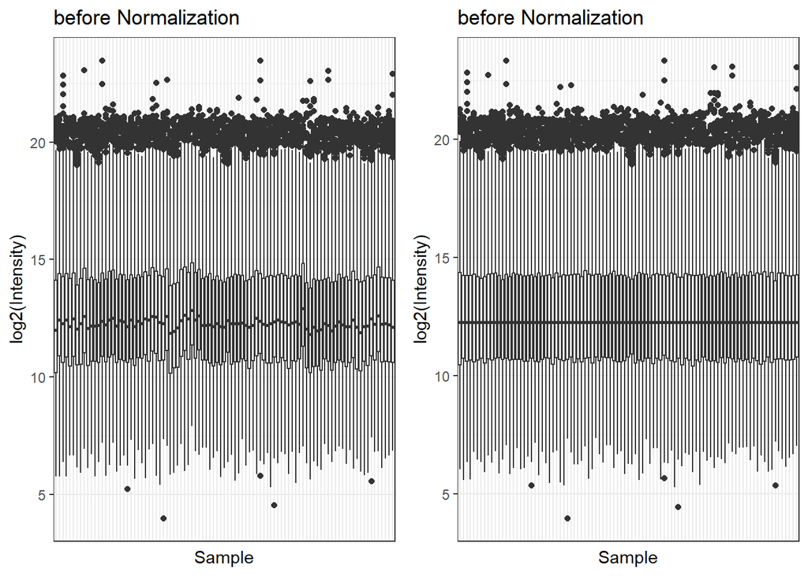

```r
#OR if you do not have pool dont specify and it wont delete them.

example_without_outliers_normalized_medianIntens_withPool <- normalize_medianintensity(example_without_outliers)
```

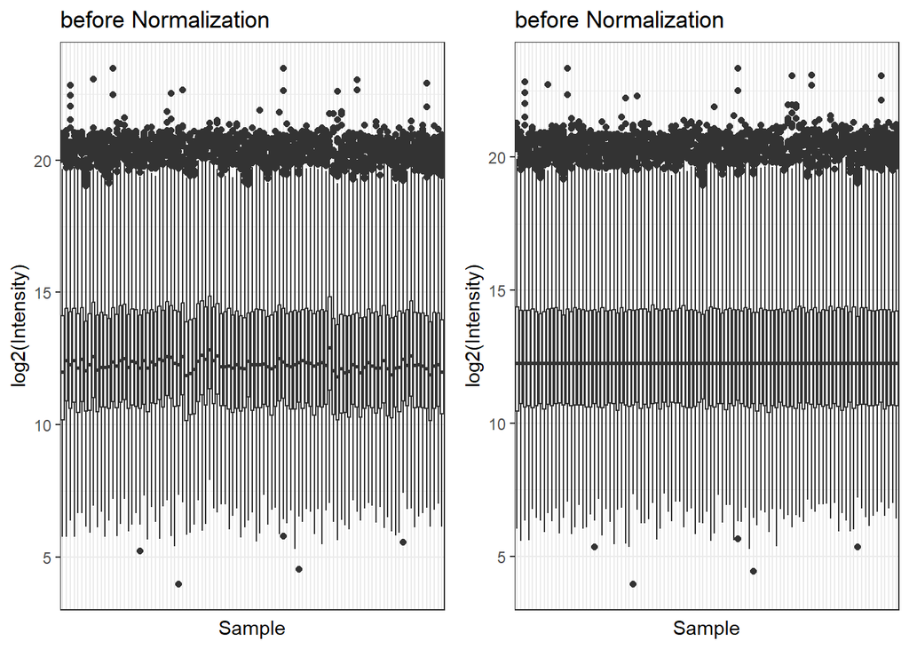

## Normalize - VSN

VSN normalization. Assumed log2 transformed data. check the following DOI doi: 10.1093/bib/bbw095

```r
#VSN normalization. Assumed log2 transformed data.
#check the following DOI
# doi: 10.1093/bib/bbw095

normalize_vsn <- function(dataset, string_of_pool = ""){

  if (string_of_pool != ""){
    print("Info on Pools were included. They are used to determine summed Intensity but removed downstream.")
    dataset <- dataset %>%
      dplyr::filter(!grepl(string_of_pool, Sample))
  }

  RawMatrix <- dataset %>%
    mutate(Intensity = 2^Intensity) %>%
    spread(Protein, Intensity) %>%
    column_to_rownames("Sample")

  normMatrix <- data.frame(suppressMessages(vsn::justvsn(as.matrix(RawMatrix), ))) %>%
    rownames_to_column(var = "Sample")

  dataset_normalized <- tidyr::gather(normMatrix, colnames(normMatrix)[2:ncol(normMatrix)], key = "Protein", value = "Intensity")

  boxplot_before <-
    dataset %>%
    ggplot(aes(x = Sample, y = Intensity)) +
    geom_boxplot() +
    theme_bw() +
    theme(axis.ticks.x = element_blank(), axis.text.x = element_blank()) +
    ggtitle("before Normalization") +
    ylab("log2(Intensity)")

  boxplot_after <-
    dataset_normalized %>%
    ggplot(aes(x = Sample, y = Intensity)) +
    geom_boxplot() +
    theme_bw() +
    theme(axis.ticks.x = element_blank(), axis.text.x = element_blank()) +
    ggtitle("before Normalization") +
    ylab("log2(Intensity)")

  plot(ggarrange(boxplot_before, boxplot_after, nrow = 1))

  return(dataset_normalized)

}
```

```r
example_without_outliers_normalized_vsnIntens_withPool <- normalize_vsn(example_without_outliers, string_of_pool = "Pool")
```

```
## [1] "Info on Pools were included. They are used to determine summed Intensity but removed downstream."
```

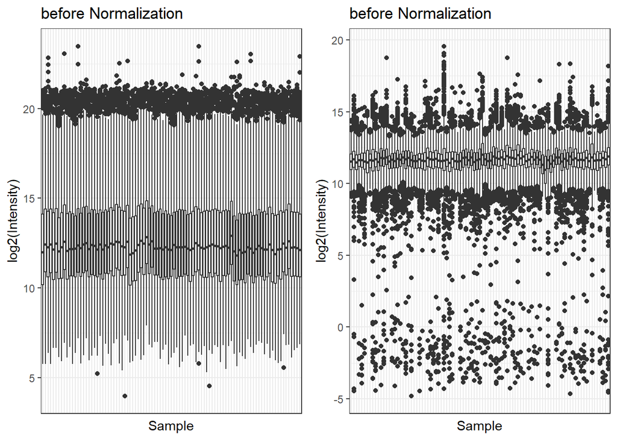

```r
#OR if you do not have pool dont specify and it wont delete them.

example_without_outliers_normalized_vsnIntens_withPool <- normalize_vsn(example_without_outliers)
```

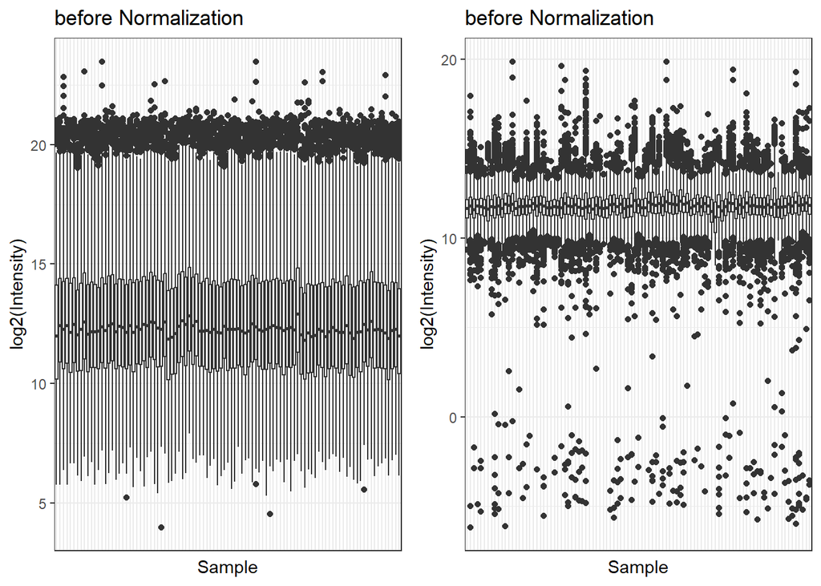

## Normalize - LOESS

LOESS normalization. Assumed log2 transformed data. check the following DOI doi: 10.1093/bib/bbw095

```r
normalize_loess <- function(dataset, string_of_pool = ""){

  if (string_of_pool != ""){
    print("Info on Pools were included. They are used to determine summed Intensity but removed downstream.")
    dataset <- dataset %>%
      dplyr::filter(!grepl(string_of_pool, Sample))
  }

  RawMatrix <- dataset %>%
    mutate_all(~replace(., . == 0, NA)) %>%
    spread(Protein, Intensity) %>%
    column_to_rownames("Sample")

  normMatrix <- data.frame(limma::normalizeCyclicLoess(as.matrix(RawMatrix), method="fast")) %>%
    rownames_to_column(var = "Sample")

  dataset_normalized <- tidyr::gather(normMatrix, colnames(normMatrix)[2:ncol(normMatrix)], key = "Protein", value = "Intensity")

  boxplot_before <-
    dataset %>%
    ggplot(aes(x = Sample, y = Intensity)) +
    geom_boxplot() +
    theme_bw() +
    theme(axis.ticks.x = element_blank(), axis.text.x = element_blank()) +
    ggtitle("before Normalization") +
    ylab("log2(Intensity)")

  boxplot_after <-
    dataset_normalized %>%
    ggplot(aes(x = Sample, y = Intensity)) +
    geom_boxplot() +
    theme_bw() +
    theme(axis.ticks.x = element_blank(), axis.text.x = element_blank()) +
    ggtitle("before Normalization") +
    ylab("log2(Intensity)")

  plot(ggarrange(boxplot_before, boxplot_after, nrow = 1))

  return(dataset_normalized)
}
```

### Usage

```r
example_without_outliers_normalized_loessIntens_withPool <- normalize_loess(example_without_outliers, string_of_pool = "Pool")
```

```
## [1] "Info on Pools were included. They are used to determine summed Intensity but removed downstream."
```

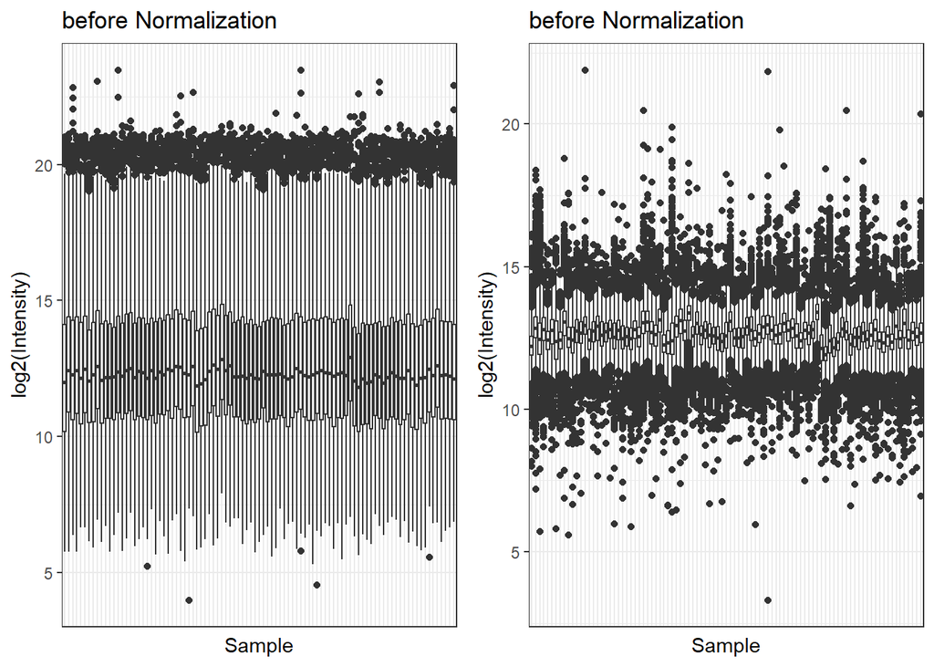

```r
#OR if you do not have pool dont specify and it wont delete them.

example_without_outliers_normalized_loessIntens_withPool <- normalize_loess(example_without_outliers)
```

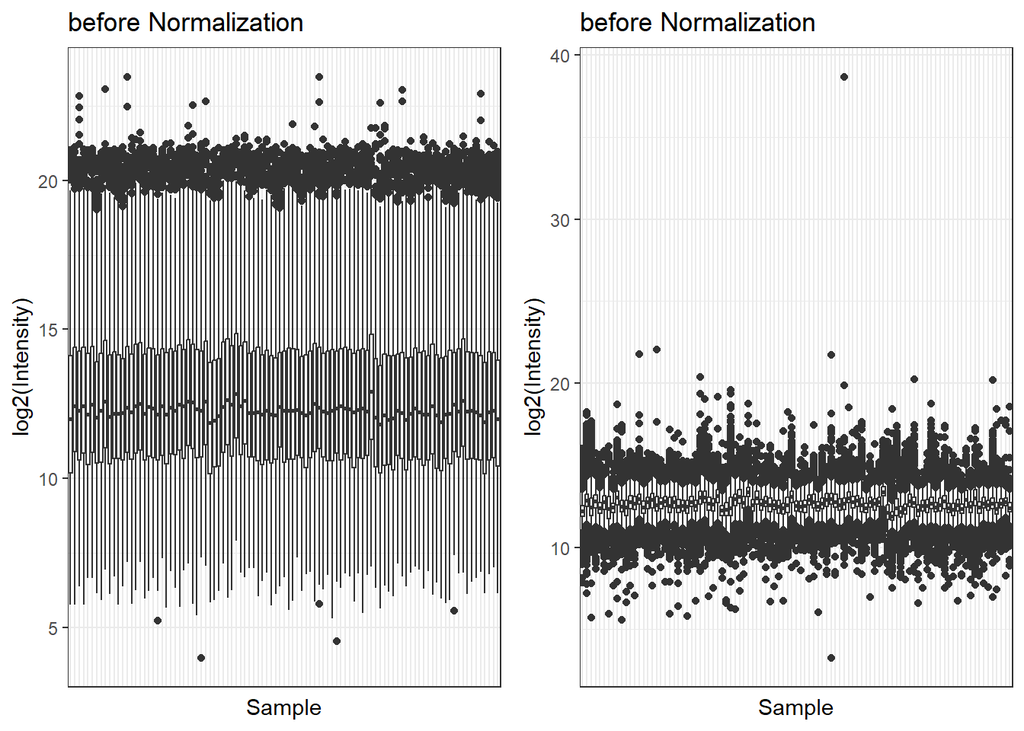